# Learning Seurat

Axel Almet

04/06/2020

This file details all of our attempts to familiarise myself with the popular single-cell RNA-seq (scRNA-seq) analysis package, [Seurat](https://satijalab.org/seurat/).

## Guided clustering tutorial

Essentially, we are following the [Seurat tutorial](https://satijalab.org/seurat/v3.1/pbmc3k_tutorial.html) on analysis of the scRNA-seq dataset of the PBMC_3k dataset from 10X genomics. Namely, we look at clustering and normalisation. Let’s first load teh dataset

```r
# Load the dataset
pbmc.data <- Read10X(data.dir="~/Documents/SingleCellRNASeq/filtered_gene_bc_matrices/hg19/")

# Initialise the Seurat object (with the raw, non-normalised data)
pbmc <- CreateSeuratObject(counts = pbmc.data, project="pbmc3k", min.cells = 3, min.features = 200)
pbmc
```

```
## An object of class Seurat
## 13714 features across 2700 samples within 1 assay
## Active assay: RNA (13714 features, 0 variable features)
```

This is what the matrix looks like

```r
# Lot of zeros...
pbmc.data[c("CD3D", "TCL1A", "MS4A1"), 1:30]
```

```
## 3 x 30 sparse Matrix of class "dgCMatrix"
```

```
##    [[ suppressing 30 column names 'AAACATACAACCAC-1', 'AAACATTGAGCTAC-1', 'AAACATTGATCAGC-1' ... ]]
```

```
##
## CD3D  4 . 10 . . 1 2 3 1 . . 2 7 1 . . 1 3 . 2  3 . . . . . 3 4 1 5
## TCL1A . .  . . . . . . 1 . . . . . . . . . . .  . 1 . . . . . . . .
## MS4A1 . 6  . . . . . . 1 1 1 . . . . . . . . . 36 1 2 . . 2 . . . .
```

Show the metadata for the first five cells.

```r
head(pbmc@meta.data, 5) # Show the metadata for the first five cells
```

```
##                  orig.ident nCount_RNA nFeature_RNA
## AAACATACAACCAC-1     pbmc3k       2419          779
## AAACATTGAGCTAC-1     pbmc3k       4903         1352
## AAACATTGATCAGC-1     pbmc3k       3147         1129
## AAACCGTGCTTCCG-1     pbmc3k       2639          960
## AAACCGTGTATGCG-1     pbmc3k        980          521
```

We use quality control (QC) plots to determine how we should filter out certain genes. See [Ilicic et al. (2016)](https://genomebiology.biomedcentral.com/articles/10.1186/s13059-016-0888-1) for more info. Examples of QC metrics include: Low-quality/empty droplets have very few genes * Cell doublets/multiplets have an unusually-high gene count, i.e. you could mistake multiple cells for a single cell. * Low-quality/dying cells often exhibit extensive mitochondrial contamination. * The total number of molecules detected correlates strongly with the number of unique genes.

Let’s first calculate what percentage of genes within each cell are associated with mitochondrical genes

```r
pbmc[["percent.mt"]] <- PercentageFeatureSet(pbmc, pattern="^MT-") # The [[]] operator adds columns to store metadata
```

We examine Violin plots of certain QC metrics, such as the unique feature counts and % of mitochondrial genes.

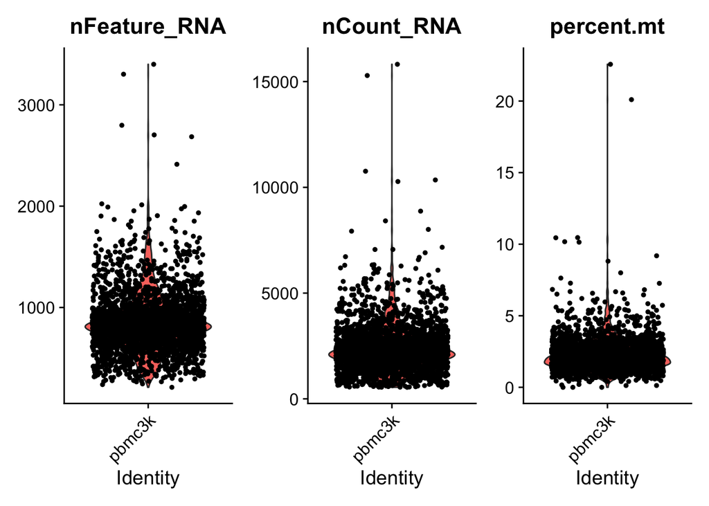

```r
VlnPlot(pbmc, features = c("nFeature_RNA", "nCount_RNA", "percent.mt"), ncol = 3)
```

We can also examine how these features relate to each other using the FeatureScatter function. The function also seems to calculate the Pearson coefficient.

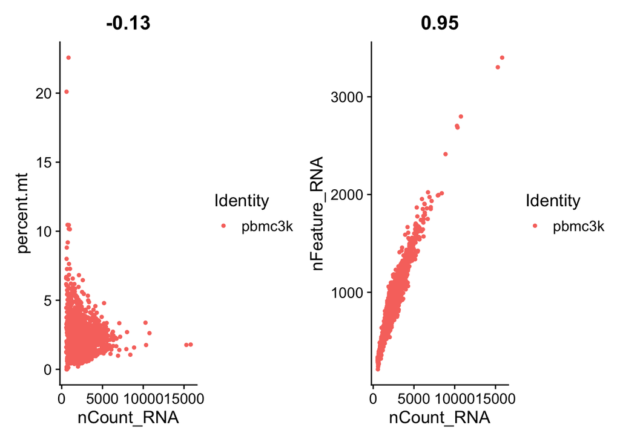

```r
plot1 <- FeatureScatter(pbmc, feature1="nCount_RNA", feature2="percent.mt")
plot2 <- FeatureScatter(pbmc, feature1="nCount_RNA", feature2="nFeature_RNA")
plot1 + plot2
```

```r
pbmc <- subset(pbmc, subset = nFeature_RNA > 200 & nFeature_RNA < 2500 & percent.mt < 5)
```

After filtering, we now normalise the data. We employ a global-scaling normalisation method called ‘LogNormalize’, where we normalise the feature expression measurements for each cell by the total epxression, multiply the resulting normalisation by a scale factor (usually 10, 000), then take the log. Normalised values are stored in pmbc[[“RNA”]]@data.

```r
pbmc <- NormalizeData(pbmc, normalization.method = "LogNormalize", scale.factor = 10000) # This method and scale factor are actually the default
```

We now calculate and identify a subset of features that exhibit high cell-to-cell variation in the dataset. That is, features that are expressed highly in some cells, and expressed lowly in others. The [claim](https://www.nature.com/articles/nmeth.2645) is that this helps to highlight biological signal in downstream analysis. Seurat’s method is to model the variance of expression as a function of the mean expression within cells. The features returned are then used in downstream analysis like Principal Component Analysis (PCA). We will also highlight the 10 most highly variable genes.

```r
pbmc <- FindVariableFeatures(pbmc, selection.method="vst", nfeatures = 2000)

top10 <- head(VariableFeatures(pbmc), 10) # Identify the top 10 most variable genes

# Plot the variable features, unlabelled and unlabelled.
plot1 <- VariableFeaturePlot(pbmc)
plot2 <- LabelPoints(plot = plot1, points = top10, repel = TRUE)
```

```
## When using repel, set xnudge and ynudge to 0 for optimal results
```

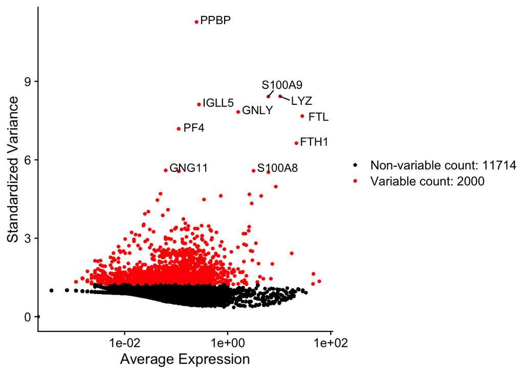

```r
# plot1 + plot2
plot2
```

Before applying dimensional reduction techniques like PCA or UMAP, it’s convention to scale the data via a linear transformation. The ScaleData function shifts the expression of each gene, such that the mean expression across cells is 0 and scales the expression across each gene so that the variance across cells is 1. Scaling the variance gives equal weight in the downstream analysis, so that the highly-expressed genes do not dominate. These results can be accessed in pbmc[[“RNA”]]@scale.data

```r
all.genes <- rownames(pbmc)
pbmc <- ScaleData(pbmc, features = all.genes)
```